# EDAV Fall 2024 Community Contribution

Author

Yunyan Ouyang

# How to visualize t-test and ANOVA result using ggstatsplot in R？

## 1. Introduction

### 1.1. what is ggstatsplot?

- `ggstatsplot` is an extension package of `ggplot2`. It can create graphics with statistical tests results, which allows researchers and analysts to effectively understand the significance of the data being presented.
- It supports most common types of statistical tests such as: parametric, nonparametric, robust, and Bayesian versions of t-test/ANOVA, correlation analyses, contingency table analysis, meta-analysis, and regression analyses.

  References: Patil (2021); https://cran.r-project.org/web/packages/ggstatsplot/index.html

### 1.2 what this video will cover

In this video, I will focus on visualizing t-test and ANOVA results using the `ggstatsplot` package.

T-tests and ANOVA are commonly used statistical methods in data analysis across various fields, including psychology, medicine, and social sciences. Both methods are used to compare differences between groups, depending on the number of groups and variables involved. This tutorial will be organized by the number of groups and variables, guiding you on how to choose the appropriate statistical test for different scenarios.

- One variable
  - One group against an hypothesis number: **t-test**
  - Two groups comparisons:
    - Between-groups (each participant is exposed to only one condition or treatment): **independent t-test**
    - Within-groups (the same participants are exposed to all conditions or treatments): **repeated t-test**
  - Three groups or more comparisons
    - between-groups: **One-way ANOVA**
    - within-groups: **One-way repeated measures ANOVA**
- Two variables: **Two-way ANOVA**

## 2. Preparation:

### 2.1 Install and load packages:

```r
# install.packages("ggstatsplot")
library(ggstatsplot)
library(ggplot2)
library(dplyr)
```

### 2.2 Dataset: mtcars (between group), ToothGrowth (within group)

For our analysis, we’ll use the `mtcars` dataset to explore between-group comparisons and the `ToothGrowth` dataset for within-group comparisons.

- **mtcars**: This dataset show the performance for various car models. It contains several variables, such as `mpg` (miles per gallon), `cyl` (number of cylinders), and `gear` (number of forward gears). This dataset will help us explore how the number of cylinders and gears affects fuel efficiency.

```r
head(mtcars)
```

```
                   mpg cyl disp  hp drat    wt  qsec vs am gear carb
Mazda RX4         21.0   6  160 110 3.90 2.620 16.46  0  1    4    4
Mazda RX4 Wag     21.0   6  160 110 3.90 2.875 17.02  0  1    4    4
Datsun 710        22.8   4  108  93 3.85 2.320 18.61  1  1    4    1
Hornet 4 Drive    21.4   6  258 110 3.08 3.215 19.44  1  0    3    1
Hornet Sportabout 18.7   8  360 175 3.15 3.440 17.02  0  0    3    2
Valiant           18.1   6  225 105 2.76 3.460 20.22  1  0    3    1
```

- **ToothGrowth**: This dataset contains the results of an experiment examining the effect of different doses of vitamin C (in three different doses) on the tooth length of guinea pigs. It includes two categorical variables: `supp` (the type of supplement, either orange juice or ascorbic acid) and `dose` (the dose of the supplement).

```r
head(ToothGrowth)
```

```
   len supp dose
1  4.2   VC  0.5
2 11.5   VC  0.5
3  7.3   VC  0.5
4  5.8   VC  0.5
5  6.4   VC  0.5
6 10.0   VC  0.5
```

## 3. Test and Visualization

### 3.1 One variable

#### 3.1.1 One group against an hypothesis number: **t-test**

Visualize the distribution of a single variable (average miles per gallon, MPG) and test if its mean is significantly different from a specified value (20) with one-sample t-test.

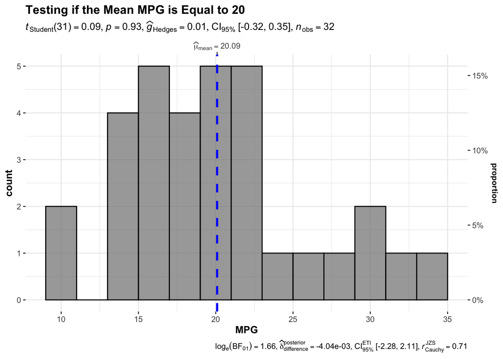

```r
gghistostats(
  data = mtcars,
  x = mpg,
  title = "Testing if the Mean MPG is Equal to 20",
  xlab = "MPG",
  ylab = "Count",
  test.value = 20,
  binwidth = 2
)
```

#### 3.1.2 Two groups comparisons: t-test

- Between groups:

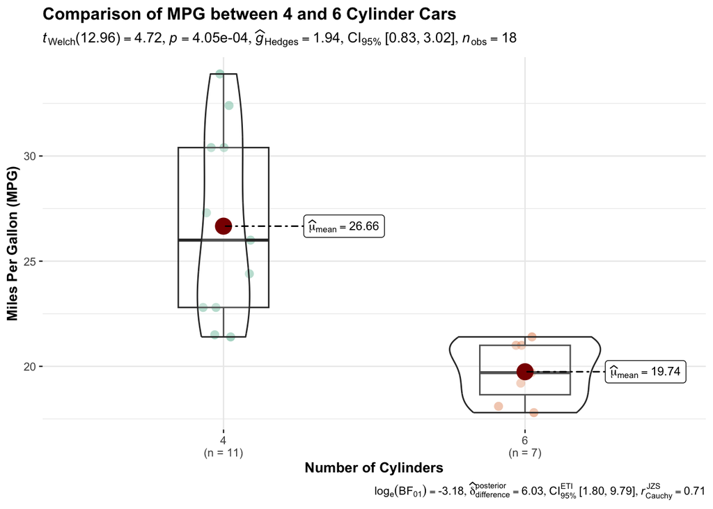

```r
# we only need two group here
mtcars_data <- mtcars |>
  filter(cyl %in% c(4, 6))

# Perform t-test comparison between groups
ggbetweenstats(
  data = mtcars_data,
  x = cyl,
  y = mpg,
  type = "t.test",  # Specify that we want to perform a t-test
  title = "Comparison of MPG between 4 and 6 Cylinder Cars",
  xlab = "Number of Cylinders",
  ylab = "Miles Per Gallon (MPG)"
)
```

- Within groups

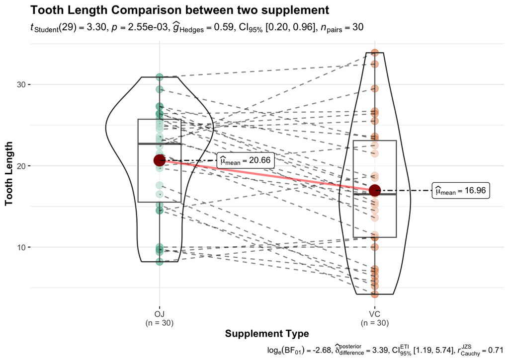

```r
ggwithinstats(
  data = ToothGrowth,
  x = supp,
  y = len,
  type = "t.test", # Specify that we want to perform an t-test
  title = "Tooth Length Comparison between two supplement",
  xlab = "Supplement Type",
  ylab = "Tooth Length",
)
```

#### 3.1.3 Three groups or more comparisons: ANOVA

- Between groups

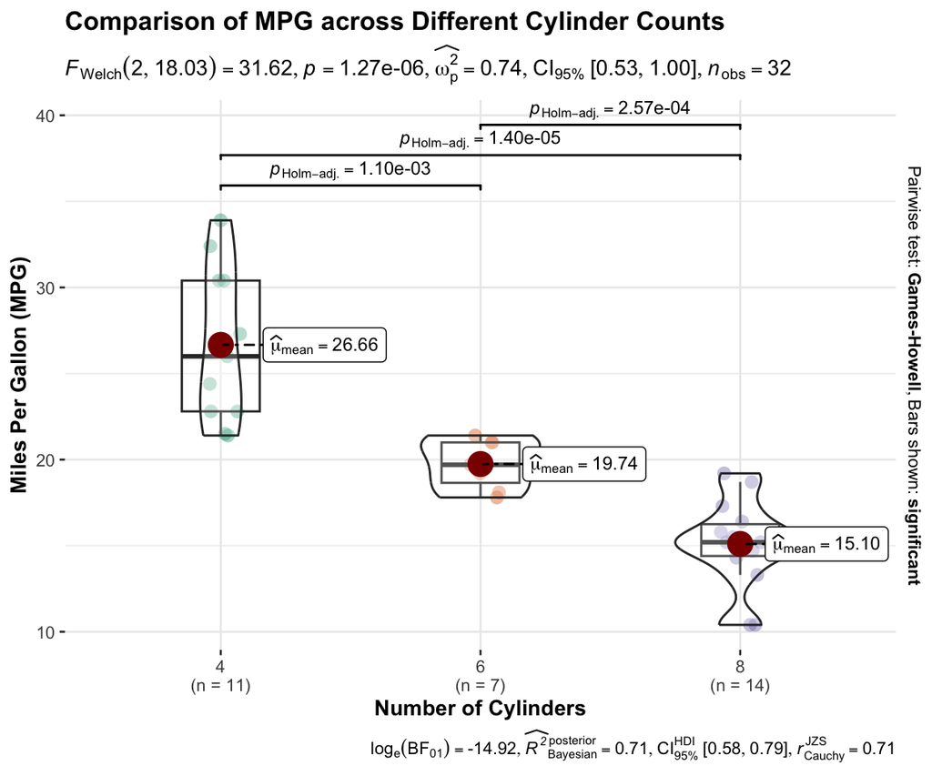

```r
ggbetweenstats(
  data = mtcars,
  x = cyl,
  y = mpg,
  type = "anova",  # Specify that we want to perform a anova
  title = "Comparison of MPG across Different Cylinder Counts",
  xlab = "Number of Cylinders",
  ylab = "Miles Per Gallon (MPG)"  # Correct label for the y-axis
)
```

- Within groups

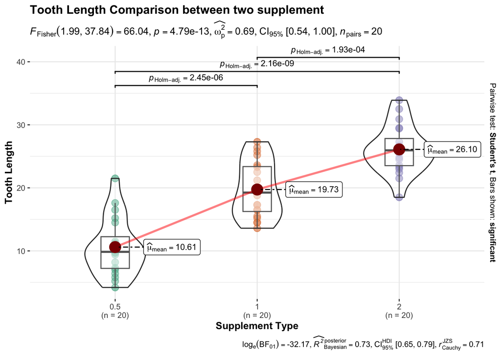

```r
ggwithinstats(
  data = ToothGrowth,
  x = dose,
  y = len,
  type = "anova", # Specify that we want to perform an ANOVA
  title = "Tooth Length Comparison between two supplement",
  xlab = "Supplement Type",
  ylab = "Tooth Length",
)
```

### 3.2 Two variables: ANOVA

- Between groups

```r
# get the two-way anova result

anova_result <- aov(mpg ~ cyl * gear, data = mtcars)
anova_summary = summary(anova_result)
print(anova_summary)
```

```
            Df Sum Sq Mean Sq F value   Pr(>F)
cyl          1  817.7   817.7  79.971 1.07e-09 ***
gear         1    5.4     5.4   0.531    0.472
cyl:gear     1   16.6    16.6   1.623    0.213
Residuals   28  286.3    10.2
---
Signif. codes:  0 '***' 0.001 '**' 0.01 '*' 0.05 '.' 0.1 ' ' 1
```

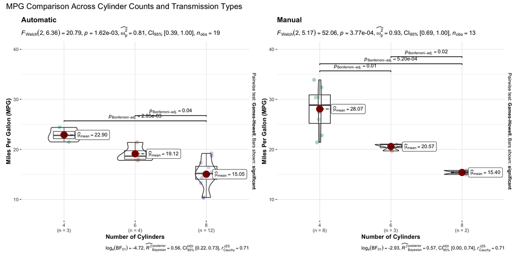

```r
p_value <- anova_summary[[1]]["cyl:gear", "Pr(>F)"]
f_value <- anova_summary[[1]]["cyl:gear", "F value"]

# Set y-axis limits for a consistent scale across plots
y_min <- min(mtcars$mpg) - 3
y_max <- max(mtcars$mpg) + 6

df <- mtcars %>%
  mutate(am = factor(am, levels = c(0, 1), labels = c("Automatic", "Manual")))
# Generate plot
grouped_ggbetweenstats(
  data = df,
  x = cyl,
  y = mpg,   # First variable
  grouping.var = am,  # Second variable
  type = "anova",        # Specify ANOVA as the test type
  p.adjust.method = "bonferroni",  # Adjust p-values for multiple comparisons
  ggplot.component = list(coord_cartesian(ylim = c(y_min, y_max)),  # Set y-axis limits
    labs(x = "Number of Cylinders",y = "Miles Per Gallon (MPG)")),
  annotation.args = list(title = "MPG Comparison Across Cylinder Counts and Transmission Types"))
```

- Within groups

```r
# get the two way anova result
anova_result <- aov(len ~ supp * dose, data = ToothGrowth)
anova_summary = summary(anova_result)
print(anova_summary)
```

```
            Df Sum Sq Mean Sq F value   Pr(>F)
supp         1  205.4   205.4  12.317 0.000894 ***
dose         1 2224.3  2224.3 133.415  < 2e-16 ***
supp:dose    1   88.9    88.9   5.333 0.024631 *
Residuals   56  933.6    16.7
---
Signif. codes:  0 '***' 0.001 '**' 0.01 '*' 0.05 '.' 0.1 ' ' 1
```

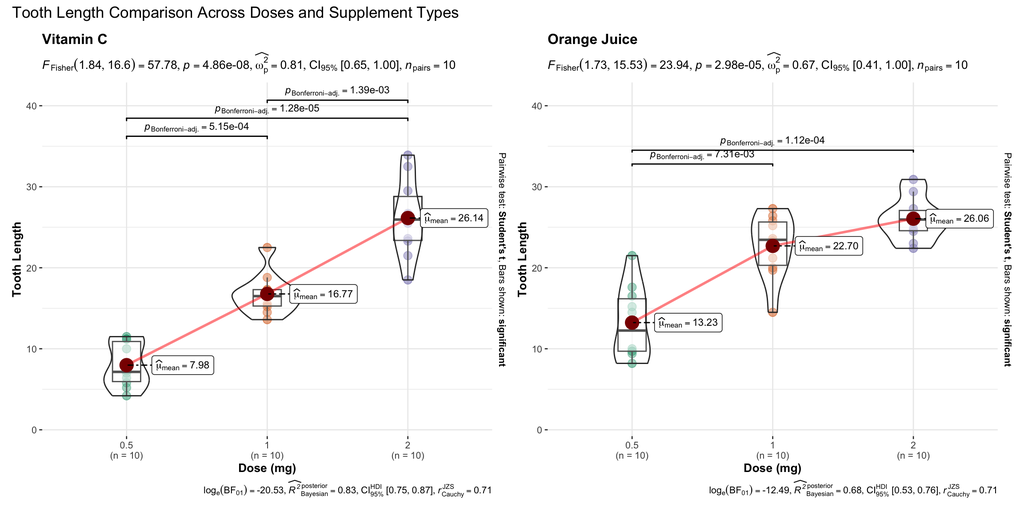

```r
p_value <- anova_summary[[1]]["supp:dose", "Pr(>F)"]
f_value <- anova_summary[[1]]["supp:dose", "F value"]

# Set y-axis limits for a consistent scale across plots
y_min <- min(ToothGrowth$len) - 3
y_max <- max(ToothGrowth$len) + 7

df <- ToothGrowth %>%
  mutate(supp = factor(supp, levels = c("VC", "OJ"), labels = c("Vitamin C", "Orange Juice")))

# Generate plot
grouped_ggwithinstats(
  data = df,
  x = dose,
  y = len, # First variable
  grouping.var = supp,  # Second variable
  type = "anova",  # Specify that we want to perform an ANOVA
  p.adjust.method = "bonferroni",
  ggplot.component = list(coord_cartesian(ylim = c(y_min, y_max)),
    labs(x = "Dose (mg)", y = "Tooth Length")),
    annotation.args = list(title = "Tooth Length Comparison Across Doses and Supplement Types"))
```